# test1

Walter Conrad

4/20/2020

My task was to create a custom random forest function that only included tree “stumps” - that is, each of the “trees” in my forest can only have a single split, and therefore instead of a tree, each element of my forest is more aptly a stump. Otherwise, the random forest of stumps is similar to a normal random forest implementation. I use the random forest of stumps to vote on a classification based upon a number of predictor variables, and I use the average vote to classify a given observation.

First I load the libraries I will need to complete this task:

```r
library(tidyverse)
library(rpart)
library(rattle)
library(fmsb)
library(caret)
```

```r
library(ggplot2)
```

Then I load some data that I can use to train and test my model. I chose to work with the titanic data set.

```r
titanic <- read_csv('titanic.csv')
```

I ‘clean’ and reorganize my data so that the response variable is in the leftmost column, and the set of possible predictor variables that I would like to use are in columns to the right of the response variable. In this format, I can pass the data table into the rpart function in order to create individual stumps. In general, it is expected that a user of my function would input their data in this way - column 1 contains the response variable, and columns 2-n contain predictors. I chose to omit some variables that had undesirable effects when creating trees; for example, using passenger names as a predictor results in a terribly biased tree with very high variance. Using passenger names to predict survival on the titanic is fairly nonsensical.

```r
titanic$Survived <- factor(titanic$Survived)
titanic.pruned <- subset(titanic, select = -c(PassengerId,Name, Ticket,Cabin))
```

Next I created a test-training split with my ‘pruned’ data set in order to train my stumps and then test their performance.

```r
indexes <- sample(nrow(titanic.pruned),
                  size = nrow(titanic.pruned)*.7)

titanic.pruned.train <- titanic.pruned[indexes, ]
titanic.pruned.test <- titanic.pruned[-indexes, ]
```

With setup complete, I can write my function. The function takes two arguments, nStumps and nVar. nStumps tells the function how many stumps to create, and nVar tells the function how many randomly selected predictor variables to show each stump when making a split.

```r
myStumps <- function(nStumps, nVar) {

  #store stumps
  forest <- list(nStumps)

  #store predictions for each stump to enable averaged voting
  preds <- list(nStumps)

  #store variable importance for each stump
  stumps.var.imp <- list(nStumps)

  for(i in 1:nStumps){

    #sample a subset of the predictor variables, as specified by nVar parameter
    vars <- sample(2:ncol(titanic.pruned.train),
                  size = nVar,
                  replace = FALSE)

    #prepare the stump data frame
    titanic.stump <- subset(titanic.pruned.train, select = c(Survived, vars))

    #create the stump and store in the forest
    forest[[i]] <- rpart(titanic.stump,
                        na.action = na.omit,
                        minsplit = 0,
                        minbucket = 0,
                        cp = .0001,
                        maxdepth = 1)

    #if the stump isn't NULL
    if(nrow(forest[[i]]$frame) == 3) {
      preds[[i]] <- ifelse(predict(forest[[i]], titanic.pruned.test)[,2]>.5,1,0)
      stumps.var.imp[[i]] <- data.frame(forest[[i]]$variable.importance)
    }
  }


  final.preds <- NULL

  #loop through each element in the test set and predict
  #survival as an average of all the stumps' votes
  for(i in 1:nrow(titanic.pruned.test)){

    final.pred <- 0
    nvotes <- 0

    for(j in 1:length(preds)){


    if(!(is.null(preds[[j]]))) {

      current_pred <- data.frame(preds[[j]])

        if(current_pred[i,] <= 1) {
          final.pred = final.pred + current_pred[i,]
          nvotes = nvotes + 1
        }

      }

    }

    final.pred = final.pred / nvotes

    final.preds[i] <- ifelse(final.pred >.5, 1,
                             ifelse(final.pred == .5, round(runif(1,0,1)), 0))
  }

  #Variable Importance
  var.imp <- list(ncol(titanic.pruned.train)-1)

  #iterate through each possible predictor
  k = 1
  for(i in colnames(titanic.pruned.train[,-1])){

    var.imp[[k]] <- data.frame(predictor = i,
                               imp = 0)

    #iterate through each stump
    for(j in 1:length(stumps.var.imp)) {

          if( !(is.null(stumps.var.imp[[j]][i,])) && !(is.na(stumps.var.imp[[j]][i,])) ) {

            var.imp[[k]][ ,2] = var.imp[[k]][ , 2] + stumps.var.imp[[j]][i,]

        }
    }

    k = k + 1
  }


  #merge all importance matrices
  overall <- data.frame(predictor = NULL,
                        imp = NULL)
  for(i in 1:length(var.imp)){
    overall <- rbind(overall, var.imp[[i]])
  }

  overall <- data.frame(overall)

  #actual survival values
  true_vals <- titanic.pruned.test$Survived

  #calculate accuracy
  accuracy <- mean(final.preds == true_vals)

  #create confusion matrix
  stumps_performance <- table(final.preds, true_vals)

  print(paste0("Kappa: ", Kappa.test(stumps_performance)))
  print(paste0("accuracy: ", accuracy))

  return(overall)
}
```

There are a few other things to note about my function. First of all, you can see that I had to include a conditional ‘if(nrow(forest[[i]]$frame) == 3)’ after creating each stump and before adding that stump to my forest. This was necessary because some of the stumps were not given enough information to make a split, and as a result they simply contained a root node. This root node was unable to make a prediction, so it should not be included in the random forest of stumps. I adjusted the control paramters of the rpart function to try to make a split as likely as possible.

My function returns a few metrics to describe its performance. Using a confusion matrix, I report a Kappa value for the random forest. Additionally, I calculate and report the accuracy of classification. The function returns a data frame called ‘overall’ that reflects the overall variable importance of predictors in this forest. By piping the function into ggplot, I can create a variable importance graph for my random forest that is the aggregate importance of each variable across all of the stumps in the forest. I display a few examples of this functionality below.

```
## [1] "Kappa: list(statistic = c(Z = 8.13421343202143), estimate = 0.542215714982918, conf.int = c(0.435576855658942, 0.648854574306895), p.value = 2.22044604925031e-16, method = \"Estimate Cohen's kappa statistics and test the null hypothesis that the extent of agreement is same as random (kappa=0…
## [2] "Kappa: Moderate agreement"
## [1] "accuracy: 0.791044776119403"
```

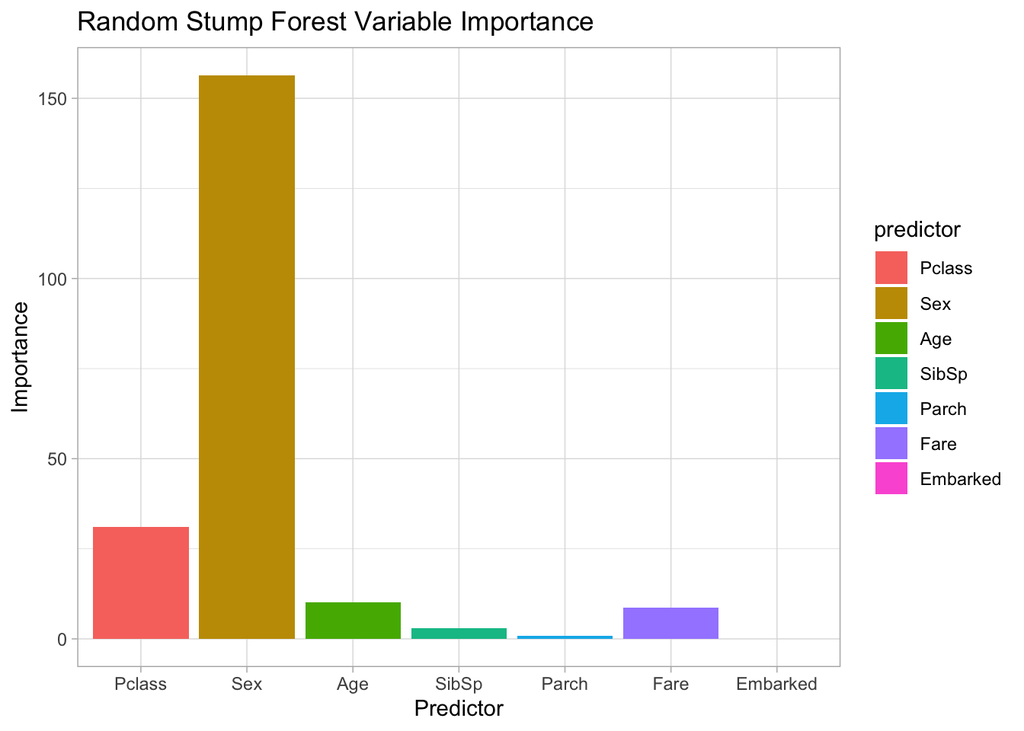

```r
myStumps(3,4) %>%
  ggplot(aes(x = predictor,
             y = imp,
             fill = predictor)) +
  geom_bar(stat = 'identity') +
  xlab('Predictor') +
  ylab('Importance') +
  ggtitle('Random Stump Forest Variable Importance') +
  theme_light()
```

```
## [1] "Kappa: list(statistic = c(Z = 8.13421343202143), estimate = 0.542215714982918, conf.int = c(0.435576855658942, 0.648854574306895), p.value = 2.22044604925031e-16, method = \"Estimate Cohen's kappa statistics and test the null hypothesis that the extent of agreement is same as random (kappa=0…
## [2] "Kappa: Moderate agreement"
## [1] "accuracy: 0.791044776119403"
```

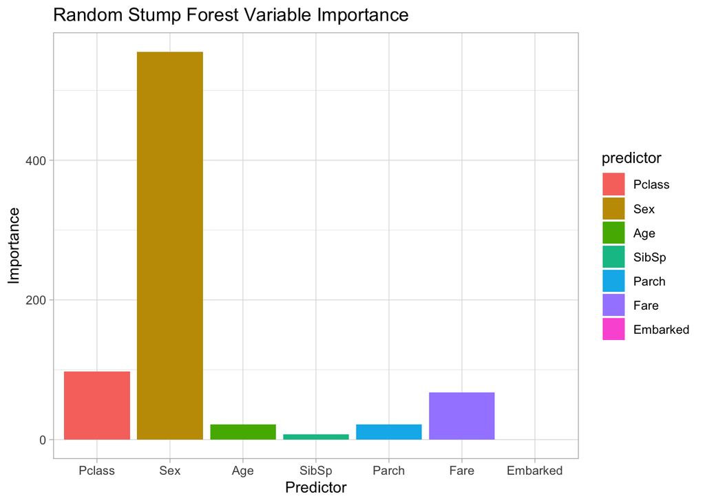

```r
myStumps(10,4) %>%
  ggplot(aes(x = predictor,
             y = imp,
             fill = predictor)) +
  geom_bar(stat = 'identity') +
  xlab('Predictor') +
  ylab('Importance') +
  ggtitle('Random Stump Forest Variable Importance') +
  theme_light()
```

```
## [1] "Kappa: list(statistic = c(Z = 8.13421343202143), estimate = 0.542215714982918, conf.int = c(0.435576855658942, 0.648854574306895), p.value = 2.22044604925031e-16, method = \"Estimate Cohen's kappa statistics and test the null hypothesis that the extent of agreement is same as random (kappa=0…
## [2] "Kappa: Moderate agreement"
## [1] "accuracy: 0.791044776119403"
```

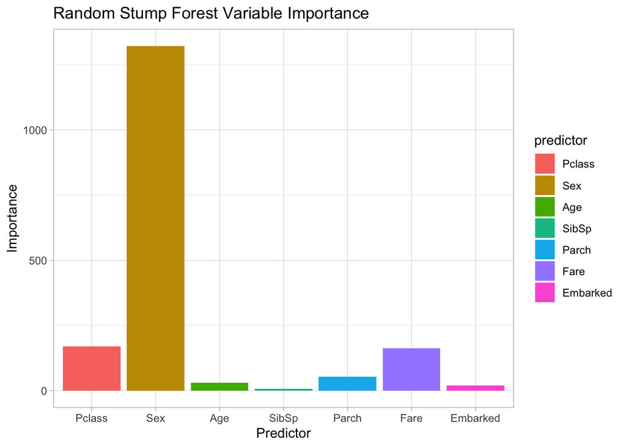

```r
myStumps(25,4) %>%
  ggplot(aes(x = predictor,
             y = imp,
             fill = predictor)) +
  geom_bar(stat = 'identity') +
  xlab('Predictor') +
  ylab('Importance') +
  ggtitle('Random Stump Forest Variable Importance') +
  theme_light()
```

Finally it’s time to compare the performance of my algorithm against a random forest package. Creating a graphic to compare the models was a bit of a lengthy process. I’d be interested to learn an easier way! I ran the “ranger” method for implementing a random forest with a tuneGrid paramter containing different values for mtry. I ran the model 3 times for 3 different values for number of trees in the forest: 10, 25, and 100.

```r
tune.grid <- expand.grid(mtry = 3:5,
                         splitrule = 'gini',
                         min.node.size = 1)

rf_model1 <- train(Survived ~ .,
                   data = titanic.pruned.train,
                   num.trees = 100,
                   na.action = na.omit,
                   tuneGrid = tune.grid,
                   method = "ranger")

compare1 <- rf_model1$results[,-c(2,3,6,7)]

compare1 <- compare1 %>%
  mutate(trees = 100)


rf_model2 <- train(Survived ~ .,
                   data = titanic.pruned.train,
                   num.trees = 10,
                   na.action = na.omit,
                   tuneGrid = tune.grid,
                   method = "ranger")

compare2 <- rf_model2$results[,-c(2,3,6,7)]

compare2 <- compare2 %>%
  mutate(trees = 10)

rf_model3 <- train(Survived ~ .,
                   data = titanic.pruned.train,
                   num.trees = 25,
                   na.action = na.omit,
                   tuneGrid = tune.grid,
                   method = "ranger")


compare3 <- rf_model3$results[,-c(2,3,6,7)]

compare3 <- compare1 %>%
  mutate(trees = 25)
```

Then I combined these results in one table for the ranger method.

```r
compare.ranger <- rbind(compare1,compare2, compare3)

compare.ranger <- compare.ranger %>%
  mutate(method = 'ranger')
```

Next, I ran my function, myStumps, with each combination of these tuning parameters in order to allow for comparisons. I collected the data and then created a data frame with all of the information.

```r
stump.compare1 <- data.frame(mtry = 3,
                            Accuracy = .7687,
                            Kappa = .4622,
                            trees = 10)

stump.compare2 <- data.frame(mtry = 3,
                             Accuracy = .7799,
                             Kappa = .5156,
                             trees = 25)

stump.compare3 <- data.frame(mtry = 3,
                             Accuracy = .75,
                             Kappa = .4422,
                             trees = 100)

stump.compare4 <- data.frame(mtry = 4,
                             Accuracy = .7463,
                             Kappa = .4456,
                             trees = 10)

stump.compare5 <- data.frame(mtry = 4,
                             Accuracy = .7799,
                             Kappa = .5156,
                             trees = 25)

stump.compare6 <- data.frame(mtry = 4,
                             Accuracy = .75,
                             Kappa = .4422,
                             trees = 100)

stump.compare7 <- data.frame(mtry = 5,
                             Accuracy = .7463,
                             Kappa = .5156,
                             trees = 10)

stump.compare8 <- data.frame(mtry = 5,
                             Accuracy = .7799,
                             Kappa = .5156,
                             trees = 25)

stump.compare9 <- data.frame(mtry = 5,
                             Accuracy = .7799,
                             Kappa = .5156,
                             trees = 100)

stumps.compare <- rbind(stump.compare1,
                        stump.compare2,
                        stump.compare3,
                        stump.compare4,
                        stump.compare5,
                        stump.compare6,
                        stump.compare7,
                        stump.compare8,
                        stump.compare9)

stumps.compare <- stumps.compare %>%
  mutate(method = 'myStumps')
```

Finally, I combined the two data frames to make a data frame for overall comparison. By utilizing faceting, I was able to see the trends that emerged as a result of the tuning.

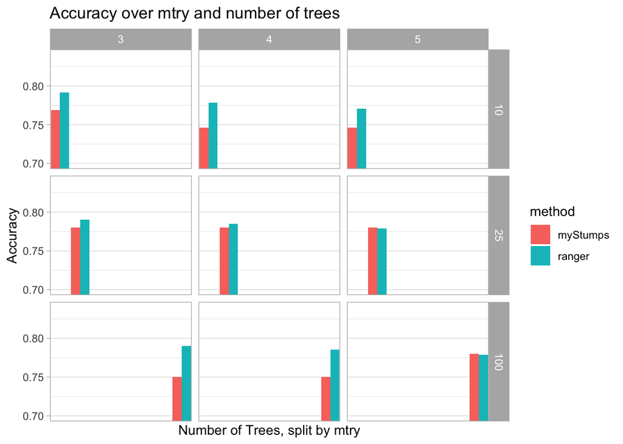

```r
overall.compare <- rbind(stumps.compare, compare.ranger)

overall.compare %>%
  ggplot(aes(x = trees,
             y = Accuracy,
             fill = method)) +
  geom_bar(stat = 'identity',
           position = 'dodge') +
  facet_grid(rows = vars(trees), cols = vars(mtry)) +
  coord_cartesian(ylim = c(.7,.84)) +
  scale_x_discrete() +
  xlab('Number of Trees, split by mtry') +
  ylab('Accuracy') +
  ggtitle('Accuracy over mtry and number of trees') +
  theme_light()
```

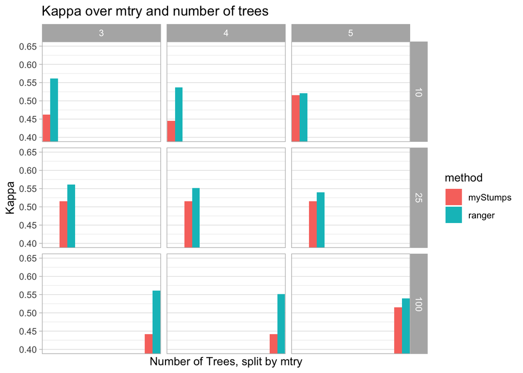

```r
overall.compare %>%
  ggplot(aes(x = trees,
             y = Kappa,
             fill = method)) +
  geom_bar(stat = 'identity',
           position = 'dodge') +
  facet_grid(rows = vars(trees), cols = vars(mtry)) +
  coord_cartesian(ylim = c(.4,.65)) +
  scale_x_discrete() +
  xlab('Number of Trees, split by mtry') +
  ylab('Kappa') +
  ggtitle('Kappa over mtry and number of trees') +
  theme_light()
```

The kappa value for myStumps was consistently lower than that for ranger. This means that the successful classifications using myStumps were a bit more the result of random chance compared to the ranger random forest. Again, this makes intuitive sense, because the random forest of stumps is much more simple than the ranger forest.

One trend that emerges is that for ranger, as mtry increases, the kappa metric decreases - it is possible that because there are only 7 predictors, using 5 out of the 7 for each split results in a forest of correlated trees that cannot predict as well as an uncorrelated forest.